# Project: No-show appointment Data Analysis

- Introduction
- Data Wrangling
- Exploratory Data Analysis
- Conclusions

## Introduction

> In this project I will be analying and investigating the data **'No-Show appointments'** collected from 100 thousand medical appiontments in Brazil. With an interest in public health, I chose this dataset because it offers me a first hand experience of handing a data which I believed to be a real-world scenario in examining public health related issues.

### Features of the data

> - ‘ScheduledDay’ tells us on what day the patient set up their appointment.
> - ‘Neighborhood’ indicates the location of the hospital.
> - ‘Scholarship’ indicates whether or not the patient is enrolled in Brasilian welfare program Bolsa Família.
> - ‘No_show’ it says ‘No’ if the patient showed up to their appointment, and ‘Yes’ if they did not show up.

```python
#importing all the neccesary packages

import pandas as pd
import numpy as np
import matplotlib.pyplot as plt
import seaborn as sns
%matplotlib inline
```

## Data Wrangling

> In this section of the report, I will load in the data, check for cleanliness, and then trim and clean the dataset for analysis.

### General Properties

```python
# Load your data and print out a few lines.
df= pd.read_csv('noshowappointments-kagglev2-may-2016.csv')
df.head()
```

|  | PatientId | AppointmentID | Gender | ScheduledDay | AppointmentDay | Age | Neighbourhood | Scholarship | Hipertension | Diabetes | Alcoholism | Handcap | SMS_received | No-show |
| --- | --- | --- | --- | --- | --- | --- | --- | --- | --- | --- | --- | --- | --- | --- |
| 0 | 2.987250e+13 | 5642903 | F | 2016-04-29T18:38:08Z | 2016-04-29T00:00:00Z | 62 | JARDIM DA PENHA | 0 | 1 | 0 | 0 | 0 | 0 | No |
| 1 | 5.589978e+14 | 5642503 | M | 2016-04-29T16:08:27Z | 2016-04-29T00:00:00Z | 56 | JARDIM DA PENHA | 0 | 0 | 0 | 0 | 0 | 0 | No |
| 2 | 4.262962e+12 | 5642549 | F | 2016-04-29T16:19:04Z | 2016-04-29T00:00:00Z | 62 | MATA DA PRAIA | 0 | 0 | 0 | 0 | 0 | 0 | No |
| 3 | 8.679512e+11 | 5642828 | F | 2016-04-29T17:29:31Z | 2016-04-29T00:00:00Z | 8 | PONTAL DE CAMBURI | 0 | 0 | 0 | 0 | 0 | 0 | No |
| 4 | 8.841186e+12 | 5642494 | F | 2016-04-29T16:07:23Z | 2016-04-29T00:00:00Z | 56 | JARDIM DA PENHA | 0 | 1 | 1 | 0 | 0 | 0 | No |

> Looking at the data their is a disparity with the AppointmentDay, it supposed to be a day or days after the ScheduledDay but it is not

> **Note:**
> - ScheduledDay is the day the patient set up their appointment.
> - AppointmentDay is supposed to be the date of the appointment.

```python
# display the last data from the database to inspect the consistency and data layout
df.tail()
```

|  | PatientId | AppointmentID | Gender | ScheduledDay | AppointmentDay | Age | Neighbourhood | Scholarship | Hipertension | Diabetes | Alcoholism | Handcap | SMS_received | No-show |
| --- | --- | --- | --- | --- | --- | --- | --- | --- | --- | --- | --- | --- | --- | --- |
| 110522 | 2.572134e+12 | 5651768 | F | 2016-05-03T09:15:35Z | 2016-06-07T00:00:00Z | 56 | MARIA ORTIZ | 0 | 0 | 0 | 0 | 0 | 1 | No |
| 110523 | 3.596266e+12 | 5650093 | F | 2016-05-03T07:27:33Z | 2016-06-07T00:00:00Z | 51 | MARIA ORTIZ | 0 | 0 | 0 | 0 | 0 | 1 | No |
| 110524 | 1.557663e+13 | 5630692 | F | 2016-04-27T16:03:52Z | 2016-06-07T00:00:00Z | 21 | MARIA ORTIZ | 0 | 0 | 0 | 0 | 0 | 1 | No |
| 110525 | 9.213493e+13 | 5630323 | F | 2016-04-27T15:09:23Z | 2016-06-07T00:00:00Z | 38 | MARIA ORTIZ | 0 | 0 | 0 | 0 | 0 | 1 | No |
| 110526 | 3.775115e+14 | 5629448 | F | 2016-04-27T13:30:56Z | 2016-06-07T00:00:00Z | 54 | MARIA ORTIZ | 0 | 0 | 0 | 0 | 0 | 1 | No |

```python
# Using the shape to check the size of the data

df.shape
```

```
(110527, 14)
```

#### Summary Statistics

```python
# Use the describe function to get a summuary statistics of what the data
df.describe()
```

|  | PatientId | AppointmentID | Age | Scholarship | Hipertension | Diabetes | Alcoholism | Handcap | SMS_received |
| --- | --- | --- | --- | --- | --- | --- | --- | --- | --- |
| count | 1.105270e+05 | 1.105270e+05 | 110527.000000 | 110527.000000 | 110527.000000 | 110527.000000 | 110527.000000 | 110527.000000 | 110527.000000 |
| mean | 1.474963e+14 | 5.675305e+06 | 37.088874 | 0.098266 | 0.197246 | 0.071865 | 0.030400 | 0.022248 | 0.321026 |
| std | 2.560949e+14 | 7.129575e+04 | 23.110205 | 0.297675 | 0.397921 | 0.258265 | 0.171686 | 0.161543 | 0.466873 |
| min | 3.921784e+04 | 5.030230e+06 | -1.000000 | 0.000000 | 0.000000 | 0.000000 | 0.000000 | 0.000000 | 0.000000 |
| 25% | 4.172614e+12 | 5.640286e+06 | 18.000000 | 0.000000 | 0.000000 | 0.000000 | 0.000000 | 0.000000 | 0.000000 |
| 50% | 3.173184e+13 | 5.680573e+06 | 37.000000 | 0.000000 | 0.000000 | 0.000000 | 0.000000 | 0.000000 | 0.000000 |
| 75% | 9.439172e+13 | 5.725524e+06 | 55.000000 | 0.000000 | 0.000000 | 0.000000 | 0.000000 | 0.000000 | 1.000000 |
| max | 9.999816e+14 | 5.790484e+06 | 115.000000 | 1.000000 | 1.000000 | 1.000000 | 1.000000 | 4.000000 | 1.000000 |

> **Note:**
> - The spelling of Hipertension, Handcap is wrong
> - The Max age appears to be an outlier

#### Check for errors, missing data and duplicates

```python
# Use the info method to prints information and find the data types and column information
df.info()
```

```
<class 'pandas.core.frame.DataFrame'>
RangeIndex: 110527 entries, 0 to 110526
Data columns (total 14 columns):
 #   Column          Non-Null Count   Dtype
---  ------          --------------   -----
 0   PatientId       110527 non-null  float64
 1   AppointmentID   110527 non-null  int64
 2   Gender          110527 non-null  object
 3   ScheduledDay    110527 non-null  object
 4   AppointmentDay  110527 non-null  object
 5   Age             110527 non-null  int64
 6   Neighbourhood   110527 non-null  object
 7   Scholarship     110527 non-null  int64
 8   Hipertension    110527 non-null  int64
 9   Diabetes        110527 non-null  int64
 10  Alcoholism      110527 non-null  int64
 11  Handcap         110527 non-null  int64
 12  SMS_received    110527 non-null  int64
 13  No-show         110527 non-null  object
dtypes: float64(1), int64(8), object(5)
memory usage: 11.8+ MB
```

> The ScheduledDay, AppointmentDay is a string, needs to be converted to DateTime data\ The No-show is not following the conventional string formatting and it data type needs to be an integer

```python
# Using the isnull method which returns boolean
#True (1) for the presence of null or NaN values
# and False (0) the absence of null or NaN values

df.isnull().sum()
```

```
PatientId         0
AppointmentID     0
Gender            0
ScheduledDay      0
AppointmentDay    0
Age               0
Neighbourhood     0
Scholarship       0
Hipertension      0
Diabetes          0
Alcoholism        0
Handcap           0
SMS_received      0
No-show           0
dtype: int64
```

> No empty dataset\ The Column names are not following the conventional lower case spell and the use of underscore to clearly spelt out the names

```python
# Using the duplicated method which returns a boolean
#True (1) for the presence of duplicate
# and False (0) the absence of duplicates

df.duplicated().sum(0)
```

```
0
```

> No duplicates

```python
# Using the nunique to see how many unique each column.

df.nunique()
```

```
PatientId          62299
AppointmentID     110527
Gender                 2
ScheduledDay      103549
AppointmentDay        27
Age                  104
Neighbourhood         81
Scholarship            2
Hipertension           2
Diabetes               2
Alcoholism             2
Handcap                5
SMS_received           2
No-show                2
dtype: int64
```

> It is strange that Handcap has 5 unqiue values

```python
# Would like to group the data by handcap and see how it is distrubed among mean age

df_hand = df.groupby('Handcap').mean('Age')
df_hand.head()
```

| Handcap | PatientId | AppointmentID | Age | Scholarship | Hipertension | Diabetes | Alcoholism | SMS_received |
| --- | --- | --- | --- | --- | --- | --- | --- | --- |
| 0 | 1.478153e+14 | 5.675150e+06 | 36.810465 | 0.098655 | 0.192389 | 0.069667 | 0.030309 | 0.322719 |
| 1 | 1.322588e+14 | 5.683177e+06 | 50.855044 | 0.078355 | 0.432419 | 0.174339 | 0.034280 | 0.239471 |
| 2 | 1.235427e+14 | 5.678123e+06 | 47.775956 | 0.098361 | 0.459016 | 0.234973 | 0.027322 | 0.234973 |
| 3 | 1.576761e+14 | 5.674417e+06 | 48.615385 | 0.000000 | 0.076923 | 0.000000 | 0.230769 | 0.230769 |
| 4 | 4.215626e+14 | 5.749102e+06 | 14.333333 | 0.000000 | 0.000000 | 0.000000 | 0.000000 | 0.333333 |

> The Handcap data is incorrect would have to drop the column or change every value greater than 1 to 1 for uniformity, since one can only be disable or not.

### Data Cleaning

```python
# First I would like to rename the column names and formate the name properly while correcting typogrphic errors
# Note: In the no_show column 'No' means that the client came for the appointment
        # and 'Yes' means that the client did not show up for the appointment

# I will change the name of no_show to show and
# then further more in the cleaning change every 'no' to '1' and every 'yes' to '0' for easy comprehension

df = df.rename(columns= {'PatientId': 'Patient_Id', 'AppointmentDay':'Appointment_Day','ScheduledDay':'Scheduled_Day',
                       'Hipertension':'Hypertension', 'No-show':'Show', 'Handcap' : 'Handicap'})
```

```python
# I will iterate through the rows in the Show column and change every no to '1' and yes to '0'

for i, value in df.iterrows():
    if value['Show'] == 'No':
        df.loc[i,'Show'] = 1
    else:
        df.loc[i,'Show'] = 0
```

```python
# let's look at the outcome
df.info()
```

```
<class 'pandas.core.frame.DataFrame'>
RangeIndex: 110527 entries, 0 to 110526
Data columns (total 14 columns):
 #   Column           Non-Null Count   Dtype
---  ------           --------------   -----
 0   Patient_Id       110527 non-null  float64
 1   AppointmentID    110527 non-null  int64
 2   Gender           110527 non-null  object
 3   Scheduled_Day    110527 non-null  object
 4   Appointment_Day  110527 non-null  object
 5   Age              110527 non-null  int64
 6   Neighbourhood    110527 non-null  object
 7   Scholarship      110527 non-null  int64
 8   Hypertension     110527 non-null  int64
 9   Diabetes         110527 non-null  int64
 10  Alcoholism       110527 non-null  int64
 11  Handicap         110527 non-null  int64
 12  SMS_received     110527 non-null  int64
 13  Show             110527 non-null  object
dtypes: float64(1), int64(8), object(5)
memory usage: 11.8+ MB
```

```python
# We observe that Show is a string, there is need to convert it to int

df['Show'] =df['Show'].astype(int)
```

```python
# Drop columns that are irrelvant to the analysis or
# with inconsistent input like AppointmentID and PatientId

df.drop('AppointmentID', axis=1, inplace=True)
```

```python
# using the lambda function to make lower case the names of the column, enhancing reablity

df.rename(columns = lambda x: x.strip().lower(), inplace=True)
```

```python
# Let's take a look at the changes in dataset
df.head()
```

|  | patient_id | gender | scheduled_day | appointment_day | age | neighbourhood | scholarship | hypertension | diabetes | alcoholism | handicap | sms_received | show |
| --- | --- | --- | --- | --- | --- | --- | --- | --- | --- | --- | --- | --- | --- |
| 0 | 2.987250e+13 | F | 2016-04-29T18:38:08Z | 2016-04-29T00:00:00Z | 62 | JARDIM DA PENHA | 0 | 1 | 0 | 0 | 0 | 0 | 1 |
| 1 | 5.589978e+14 | M | 2016-04-29T16:08:27Z | 2016-04-29T00:00:00Z | 56 | JARDIM DA PENHA | 0 | 0 | 0 | 0 | 0 | 0 | 1 |
| 2 | 4.262962e+12 | F | 2016-04-29T16:19:04Z | 2016-04-29T00:00:00Z | 62 | MATA DA PRAIA | 0 | 0 | 0 | 0 | 0 | 0 | 1 |
| 3 | 8.679512e+11 | F | 2016-04-29T17:29:31Z | 2016-04-29T00:00:00Z | 8 | PONTAL DE CAMBURI | 0 | 0 | 0 | 0 | 0 | 0 | 1 |
| 4 | 8.841186e+12 | F | 2016-04-29T16:07:23Z | 2016-04-29T00:00:00Z | 56 | JARDIM DA PENHA | 0 | 1 | 1 | 0 | 0 | 0 | 1 |

```python
# Here I would be changing the scheduled_day and appointment_day datatype from string to DateTime
df['scheduled_day'] = pd.to_datetime(df['scheduled_day'])
df['appointment_day'] = pd.to_datetime(df['appointment_day'])
```

```python
# Let's see the changes to the datatype
df.info()
```

```
<class 'pandas.core.frame.DataFrame'>
RangeIndex: 110527 entries, 0 to 110526
Data columns (total 13 columns):
 #   Column           Non-Null Count   Dtype
---  ------           --------------   -----
 0   patient_id       110527 non-null  float64
 1   gender           110527 non-null  object
 2   scheduled_day    110527 non-null  datetime64[ns, UTC]
 3   appointment_day  110527 non-null  datetime64[ns, UTC]
 4   age              110527 non-null  int64
 5   neighbourhood    110527 non-null  object
 6   scholarship      110527 non-null  int64
 7   hypertension     110527 non-null  int64
 8   diabetes         110527 non-null  int64
 9   alcoholism       110527 non-null  int64
 10  handicap         110527 non-null  int64
 11  sms_received     110527 non-null  int64
 12  show             110527 non-null  int32
dtypes: datetime64[ns, UTC](2), float64(1), int32(1), int64(7), object(2)
memory usage: 10.5+ MB
```

> Nice the scheduled_day and appointment_day are now in the right format

#### Cleaning conclusion

> The data is pretty tidy and ready for exploration and analysis. There were no missing or duplicate values. All ambiguity have been resloved especially with if the patient came for the appointment or not, where '1' means the patient came for the appointment and '0' making it more uniform with other columns in the dataset, I changed the column names to lower case and corrected the spacing. I also modified the data types of several of the columns to improve readability and analysis.

## Exploratory Data Analysis

|  | patient_id | age | scholarship | hypertension | diabetes | alcoholism | handicap | sms_received | show |
| --- | --- | --- | --- | --- | --- | --- | --- | --- | --- |
| patient_id | 1.000000 | -0.004139 | -0.002880 | -0.006441 | 0.001605 | 0.011011 | -0.007916 | -0.009749 | 0.001461 |
| age | -0.004139 | 1.000000 | -0.092457 | 0.504586 | 0.292391 | 0.095811 | 0.078033 | 0.012643 | 0.060319 |
| scholarship | -0.002880 | -0.092457 | 1.000000 | -0.019729 | -0.024894 | 0.035022 | -0.008586 | 0.001194 | -0.029135 |
| hypertension | -0.006441 | 0.504586 | -0.019729 | 1.000000 | 0.433086 | 0.087971 | 0.080083 | -0.006267 | 0.035701 |
| diabetes | 0.001605 | 0.292391 | -0.024894 | 0.433086 | 1.000000 | 0.018474 | 0.057530 | -0.014550 | 0.015180 |
| alcoholism | 0.011011 | 0.095811 | 0.035022 | 0.087971 | 0.018474 | 1.000000 | 0.004648 | -0.026147 | 0.000196 |
| handicap | -0.007916 | 0.078033 | -0.008586 | 0.080083 | 0.057530 | 0.004648 | 1.000000 | -0.024161 | 0.006076 |
| sms_received | -0.009749 | 0.012643 | 0.001194 | -0.006267 | -0.014550 | -0.026147 | -0.024161 | 1.000000 | -0.126431 |
| show | 0.001461 | 0.060319 | -0.029135 | 0.035701 | 0.015180 | 0.000196 | 0.006076 | -0.126431 | 1.000000 |

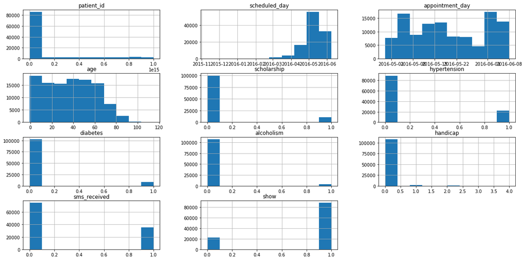

```python
#Let's take a wholistic look at the data visually

df.hist(figsize =(20,10));

df.corr().style.background_gradient(cmap='Blues')

# This would give an added advantage to see what data is what exploratory or have tendance to influence certain outcomes
```

**In my analysis I will be looking to explore age and it relationship with show (coming for their appointment) and how sms also influence show (coming for the appiontment)**

### Research Question 1: What Age Groups were most likely to showup for their appointment?

> **Note:** I will be dividing the ages into four Categories:
> - Pediatric group: 14 year old and below
> - Young group: 15 to 47 year old
> - Middle age group: 48 to 63 year old
> - Elderly group: 65 year old and above

```python
# Before starting I would like to define a functions to avoid repeating code to help categorise the age
def age_group (dateframe, columns, min_age, max_age):

    """
    The function accepts four inputs and evaluates them within
    the defined conditional statement and categorise into the
    different age brackets

    input :
    dataframe: This is the original value that will be divided by it
    columns: This will take the name of the column that will take a lifetime
    min_age: The takes lower limit age of the column
    max_age: the takes higher limit age of the column


    output :
    A new dataframe with all columns in the original one but only the rows which meet the condition.

    """
    if max_age < min_age :
        min_age, max_age = max_age , min_age

    return df.query('{} <= {} <= {}'.format(min_age, columns, max_age))
```

```python
# Below I will get dataframe for each age category
pediatric_group = df.query('age <= 14')
young_group = age_group(df,'age',15, 47)
middle_age_group = age_group(df, 'age', 48, 63)
elderly_group = df.query('age >= 65')
```

```python
# I will find the mean age for each age group that is most likely show up for the appointment

mean_pediatric_group = pediatric_group['show'].mean()
mean_young_group = young_group['show'].mean()
mean_middle_age_group = middle_age_group['show'].mean()
mean_elderly_group = elderly_group['show'].mean()
```

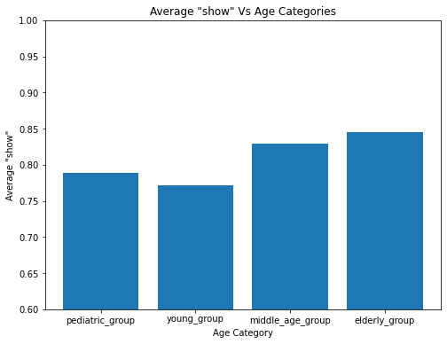

```python
# Using matplotlib I plotted the graph of 'Average Show'(Patients that made it to their appointment)
# against'Age Categories' (pediatric_group','young_group','middle_age_group','elderly_group')


locations = [1, 2, 3, 4]
heights = [mean_pediatric_group,mean_young_group,mean_middle_age_group,mean_elderly_group]
labels = ['pediatric_group','young_group','middle_age_group','elderly_group']

plt.figure(figsize=(8, 6))
plt.bar(locations,heights,tick_label = labels)
plt.title('Average "show" Vs Age Categories')
plt.ylim([0.6,1]) #Used this to set limit to the values of y axis to make the graph more visible
plt.xlabel('Age Category')
plt.ylabel('Average "show"')
plt.show();
```

> The analysis above shows that the elderly group of age 65 and above showed the most likelihood of showing up for appointments

### Research Question 2 :Does recieving SMS influence the likehood of patients showing up Appointments?

```python
# Here I would be looking at if SMS influenced the likehood of patient showing up for their appointment
# I will Groupby sms and find the mean of people that came for the appointment

sms_df = df.groupby(['sms_received'])['show'].mean()

#let's take a look at the new dataframe grouping
sms_df
```

```
sms_received
0    0.832967
1    0.724255
Name: show, dtype: float64
```

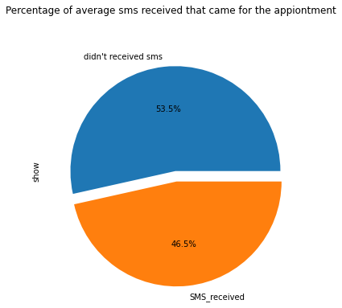

```python
# Let's see the distrubtion in percentage pie chart
label= ["didn't received sms","SMS_received"]

sms_df.plot(kind='pie', labels=label, explode=[0,0.1],autopct='%1.1f%%', figsize =(6,6))
plt.suptitle('Percentage of average sms received that came for the appiontment')
plt.show();
```

> One would have thought that sms would have influence high turn out Would could further investigate and see if the sms_received with age have significant influence

#### Further Investigation of sms data and age as it influences patients attentance

```python
# Note we have categorized our age data into four age groups. That would also be used in this analysis
# pediatric_group = df.query('age <= 14')


sms_rec = round(df.loc[(df['sms_received'] == 1 ) & (df['age']<=14)]['show'].mean(), 2)
sms_not_rec = round(df.loc[(df['sms_received']== 0 ) & (df['age'] <=14)]['show'].mean(), 2)

print('The pediatric_ group recorded {} percentage with SMS and {}  without SMS.'.format(sms_rec*100, sms_not_rec*100))
```

```
The pediatric_ group recorded 71.0 percentage with SMS and 82.0  without SMS.
```

```python
# young_group = age_group(df,'age',15, 47)

sms_rec = round(df.loc[(df['sms_received'] == 1 ) & (df['age']>14) & (df['age'] <= 47)]['show'].mean(), 2)
sms_not_rec = round(df.loc[(df['sms_received']== 0 ) & (df['age']>14) & (df['age'] <= 47)]['show'].mean(), 2)

print('The young_group recorded {} percentage with SMS and {}  without SMS.'.format(sms_rec*100, sms_not_rec*100))
```

```
The young_group recorded 68.0 percentage with SMS and 82.0  without SMS.
```

```python
# middle_age_group = age_group(df, 'age', 48, 63)

sms_rec = round(df.loc[(df['sms_received'] == 1 ) & (df['age']>47) & (df['age'] <= 63)]['show'].mean(), 2)
sms_not_rec = round(df.loc[(df['sms_received']== 0 ) & (df['age']>47) & (df['age'] <= 63)]['show'].mean(), 2)

print('The middle_age_group recorded {} percentage with SMS and {}  without SMS.'.format(sms_rec*100, sms_not_rec*100))
```

```
The middle_age_group recorded 78.0 percentage with SMS and 85.0  without SMS.
```

```python
# elderly_group = df.query('age >= 65')

sms_rec = round(df.loc[(df['sms_received'] == 1 ) & (df['age']>=65)]['show'].mean(), 2)
sms_not_rec = round(df.loc[(df['sms_received']== 0 ) & (df['age']>=65)]['show'].mean(), 2)

print('The elderly_group recorded {} percentage with SMS and {}  without SMS.'.format(sms_rec*100, sms_not_rec*100))
```

```
The elderly_group recorded 80.0 percentage with SMS and 86.0  without SMS.
```

## Conclusions

> **Limitation:**
> - The data did not show a detailed approximate distance from place of residence to the hospital which can be a huge factor in making patients not meet up with appointments
> - Also, the dataset did not give insight to the occupation and nature of work of each of the patients, we can assume that the ages of 15 to 47 is the active workforce age and schooling age, so the patients might have been carried away with work and other activities which would cause them to miss appointments but that can't be established from the dataset provide

> **Limitation:**
> - The dataset did not provide if they patients all had phones that have capacities to receieve take
> - If they did was their a feedback system to ensure the sms delivered, so we can have a dataset that shows who the sms delivered, so we can accurately measure who got the sms and did not show up for the appointment